# Practical Machine Learning - Course Project

Jeferson Bisconde

Sunday, August 24, 2014

This is the Markdown document for the Course Project for Practical Machine Learning in Coursera.

Background: The goal of this project is to predict the manner in which they did the exercise. This is the **“classe”** variable in the training set.

The data for this project come from this source: http://groupware.les.inf.puc-rio.br/har.

Using the necessary libraries to do the work:

```r
setwd("~/R/Working Directory")
library(ggplot2); library(caret); library(randomForest)
```

You can try different summarization techniques to figure out which columns to exclude.

Afterwards, remove the columns that are not important for prediction:

```r
har <- read.csv(file="pml-training.csv", header=TRUE)
harTest <- read.csv(file="pml-testing.csv", header=TRUE)
har <- har[,-nearZeroVar(har)]
har <- subset(har, select=(colMeans(is.na(har)) > 0.95) == 0)
har <- subset(har, select=-c(X, raw_timestamp_part_1,raw_timestamp_part_2,cvtd_timestamp))
```

Note that the `harTest` is the dataset that we want to predict, and `har` is the dataset we want to train and cross-validate our model.

As what we did in class, I will separate the `har` data for both training and testing (**cross-validation**).

```r
inTrain <- createDataPartition(y=har$classe, p=0.6, list=FALSE)
training <- har[inTrain,]
testing <- har[-inTrain,]
```

We will now create our model based on the training dataset.

```r
fitControl <- trainControl(number=5, allowParallel=TRUE)
modFit <- randomForest(classe ~., data=training, trControl=fitControl)
```

Now, we will evaluate our model to the testing dataset to see how accurate our model is.

```r
pred <- predict(modFit, newdata=testing)
confusionMatrix(testing$classe, pred)
```

```
## Confusion Matrix and Statistics
##
##           Reference
## Prediction    A    B    C    D    E
##          A 2231    1    0    0    0
##          B    1 1516    1    0    0
##          C    0    5 1363    0    0
##          D    0    0   13 1272    1
##          E    0    0    0    3 1439
##
## Overall Statistics
##
##                Accuracy : 0.997
##                  95% CI : (0.995, 0.998)
##     No Information Rate : 0.284
##     P-Value [Acc > NIR] : <2e-16
##
##                   Kappa : 0.996
##  Mcnemar's Test P-Value : NA
##
## Statistics by Class:
##
##                      Class: A Class: B Class: C Class: D Class: E
## Sensitivity             1.000    0.996    0.990    0.998    0.999
## Specificity             1.000    1.000    0.999    0.998    1.000
## Pos Pred Value          1.000    0.999    0.996    0.989    0.998
## Neg Pred Value          1.000    0.999    0.998    1.000    1.000
## Prevalence              0.284    0.194    0.176    0.163    0.184
## Detection Rate          0.284    0.193    0.174    0.162    0.183
## Detection Prevalence    0.284    0.193    0.174    0.164    0.184
## Balanced Accuracy       1.000    0.998    0.995    0.998    0.999
```

Success! As you can see, the Accuracy is really high! The out of sample error is only **0.0032** after cross-validation.

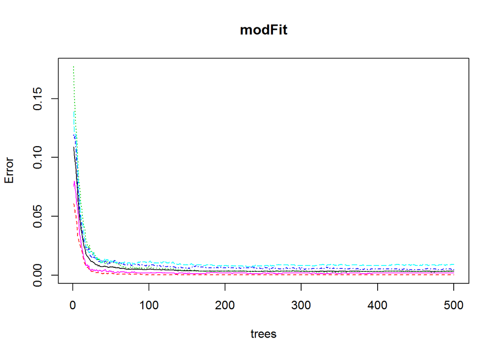

```r
plot(modFit)
```

We are now ready to submit our answer using harTest! :)